# Dimensionality reduction

Valentina Zangirolami

2025-05-16

Load libraries

```r
library(tidymodels)
library(ggplot2)
library(NMF)
library(tidyverse)
library(h2o)
```

### **Android Dataset**

```r
android_data <- read.csv("android_data.csv")
head(android_data)
```

```
##   Source.Port Destination.Port Protocol Flow.Duration Total.Fwd.Packets
## 1       46889              443       17        241803                10
## 2       57225              443        6        549471               104
## 3        2107               53       17        124148                 1
## 4       50070              443        6       7863484                 2
## 5         443            54145        6       6785797                 1
## 6       54788               80        6      12516680                 3
##   Total.Backward.Packets Total.Length.of.Fwd.Packets
## 1                     11                        4189
## 2                    339                         829
## 3                      1                          30
## 4                      0                           0
## 5                      2                           0
## 6                      1                           0
##   Total.Length.of.Bwd.Packets Fwd.Packet.Length.Max Fwd.Packet.Length.Min
```

[output cut: 90 more lines]

```r
summary(android_data)
```

```
##   Source.Port    Destination.Port    Protocol      Flow.Duration
##  Min.   :    0   Min.   :    0    Min.   : 0.000   Min.   :        1
##  1st Qu.:34661   1st Qu.:   80    1st Qu.: 6.000   1st Qu.:    49684
##  Median :43226   Median :  443    Median : 6.000   Median :   578313
##  Mean   :39210   Mean   : 5221    Mean   : 8.351   Mean   : 10879326
##  3rd Qu.:52305   3rd Qu.:  443    3rd Qu.: 6.000   3rd Qu.: 10932231
##  Max.   :65502   Max.   :60976    Max.   :17.000   Max.   :119998705
##  Total.Fwd.Packets  Total.Backward.Packets Total.Length.of.Fwd.Packets
##  Min.   :   1.000   Min.   :   0.000       Min.   :     0.0
##  1st Qu.:   1.000   1st Qu.:   0.000       1st Qu.:     0.0
##  Median :   2.000   Median :   1.000       Median :    31.0
##  Mean   :   6.734   Mean   :   8.453       Mean   :   587.9
##  3rd Qu.:   5.000   3rd Qu.:   4.000       3rd Qu.:   451.0
##  Max.   :1405.000   Max.   :4320.000       Max.   :105183.0
##  Total.Length.of.Bwd.Packets Fwd.Packet.Length.Max Fwd.Packet.Length.Min
##  Min.   :      0             Min.   :   0.0        Min.   :   0.00
##  1st Qu.:      0             1st Qu.:   0.0        1st Qu.:   0.00
##  Median :     31             Median :  31.0        Median :   0.00
##  Mean   :   8389             Mean   : 213.3        Mean   :  12.93
##  3rd Qu.:    317             3rd Qu.: 364.0        3rd Qu.:  12.00
##  Max.   :6061609             Max.   :1460.0        Max.   :1460.00
##  Fwd.Packet.Length.Mean Fwd.Packet.Length.Std Bwd.Packet.Length.Max
##  Min.   :   0.00        Min.   :  0.00        Min.   :   0.0
##  1st Qu.:   0.00        1st Qu.:  0.00        1st Qu.:   0.0
##  Median :  29.00        Median :  0.00        Median :  31.0
##  Mean   :  60.69        Mean   : 80.59        Mean   : 319.4
##  3rd Qu.:  56.80        3rd Qu.:109.58        3rd Qu.: 246.0
##  Max.   :1460.00        Max.   :857.01        Max.   :1460.0
##  Bwd.Packet.Length.Mean Bwd.Packet.Length.Std  Flow.Bytes.s
##  Min.   :   0.0         Min.   :  0.0         Min.   :       0
##  1st Qu.:   0.0         1st Qu.:  0.0         1st Qu.:       0
##  Median :  15.5         Median :  0.0         Median :      87
##  Mean   : 168.7         Mean   :124.0         Mean   :   93644
##  3rd Qu.: 146.0         3rd Qu.:104.5         3rd Qu.:    2244
##  Max.   :1450.7         Max.   :808.7         Max.   :88333333
##  Flow.Packets.s      Flow.IAT.Mean        Flow.IAT.Std       Flow.IAT.Max
##  Min.   :      0.0   Min.   :        1   Min.   :       0   Min.   :        1
##  1st Qu.:      0.6   1st Qu.:    24707   1st Qu.:       0   1st Qu.:    43423
##  Median :      7.7   Median :   239659   Median :       0   Median :   355056
##  Mean   :   5842.0   Mean   :  3082163   Mean   : 2475302   Mean   :  9413473
```

[output cut: 57 more lines]

```
##  Max.   :41084       Max.   :1405.000    Max.   :105183.0   Max.   :4320.000
##  Subflow.Bwd.Bytes Init_Win_bytes_forward Init_Win_bytes_backward
##  Min.   :      0   Min.   :   -1          Min.   :   -1
##  1st Qu.:      0   1st Qu.:   31          1st Qu.:   -1
##  Median :     31   Median : 1502          Median :   -1
##  Mean   :   8389   Mean   :23664          Mean   : 1960
##  3rd Qu.:    317   3rd Qu.:65535          3rd Qu.:  349
##  Max.   :6061609   Max.   :65535          Max.   :65535
##  act_data_pkt_fwd  min_seg_size_forward    Label
##  Min.   :  0.000   Min.   :-1.00        Length:10000
##  1st Qu.:  0.000   1st Qu.:20.00        Class :character
##  Median :  0.000   Median :32.00        Mode  :character
##  Mean   :  1.377   Mean   :26.74
##  3rd Qu.:  1.000   3rd Qu.:32.00
##  Max.   :249.000   Max.   :60.00
```

```r
#split target and features
label_android <- android_data |> select(Label)
android_data <- android_data |> select(-Label)
```

The final goal: Detect android malware

#### **PCA**

```r
pca_recipe <- recipe(~ ., data = android_data) |>
  step_pca(all_numeric(), num_comp = 84)  # All 40 PCs for evaluation

pca_prepped <- prep(pca_recipe, android_data)
pca_variance <- tidy(pca_prepped, 1, type = "variance")

# Automated selection: Find smallest #PCs reaching 95% variance
optimal_pcs_95 <- pca_variance |>
  filter(terms == "cumulative percent variance") |>
  filter(value >= 95) |>
  slice(1) |>
  pull(component)

optimal_pcs_90 <- pca_variance |>
  filter(terms == "cumulative percent variance") |>
  filter(value >= 90) |>
  slice(1) |>
  pull(component)

optimal_pcs_85 <- pca_variance |>
  filter(terms == "cumulative percent variance") |>
  filter(value >= 85) |>
  slice(1) |>
  pull(component)

cat("Optimal #PCs:", optimal_pcs_85, "(85% variance explained)")
```

```
## Optimal #PCs: 2 (85% variance explained)
```

```r
cat("Optimal #PCs:", optimal_pcs_90, "(90% variance explained)")
```

```
## Optimal #PCs: 3 (90% variance explained)
```

```r
cat("Optimal #PCs:", optimal_pcs_95, "(95% variance explained)")
```

```
## Optimal #PCs: 4 (95% variance explained)
```

Fixing different percentage of explained variance, we can obtain the optimal number of components.

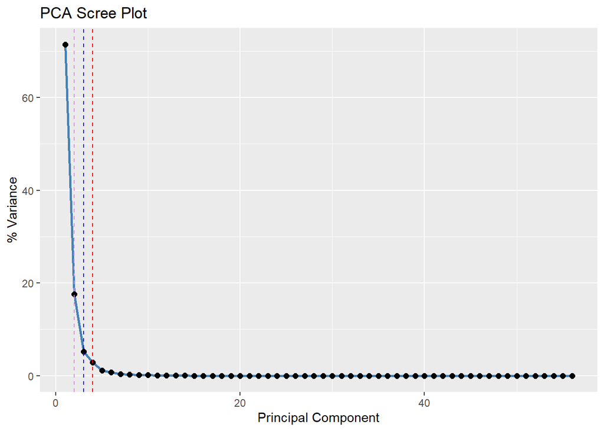

```r
pca_variance |>
  filter(terms == "percent variance") |>
  ggplot(aes(as.numeric(component), value)) +
  geom_line(color = "steelblue", linewidth = 1) +
  geom_point(size = 2) +
  geom_vline(xintercept = optimal_pcs_95, linetype = "dashed", color = "red") +
  geom_vline(xintercept = optimal_pcs_90, linetype = "dashed", color = "blue") +
  geom_vline(xintercept = optimal_pcs_85, linetype = "dashed", color = "violet") +
  labs(title = "PCA Scree Plot", x = "Principal Component", y = "% Variance")
```

We can observe that we can obtain good percentage of explained variance with few components.

```r
pca_recipe_90 <- recipe(~ ., data =android_data ) %>%
  step_normalize(all_numeric()) %>%     # Center/scale numeric vars
  step_pca(all_numeric(), num_comp = 3)

pca_recipe_95 <- recipe(~ ., data =android_data) %>%
  step_normalize(all_numeric()) %>%     # Center/scale numeric vars
  step_pca(all_numeric(), num_comp = 5)
```

#### **NMF**

It is based on

$$V \approx W H$$
approximating the feature matrix with W and H.

- $W$ is the “basis” matrix with dimension $N \times K$
- $H$ is the “coefficients” matrix with dimension $K \times P$

where N is the number of observations, K is the number of latent variables and P is the number of features.

```r
android_numeric <- android_data |>
  select_if(is.numeric)  # Keeps only numeric columns

#rescale to obtain positive entries
android_nonneg <- android_numeric |>
  mutate(across(everything(), ~ .x - min(.x, na.rm = TRUE)))
```

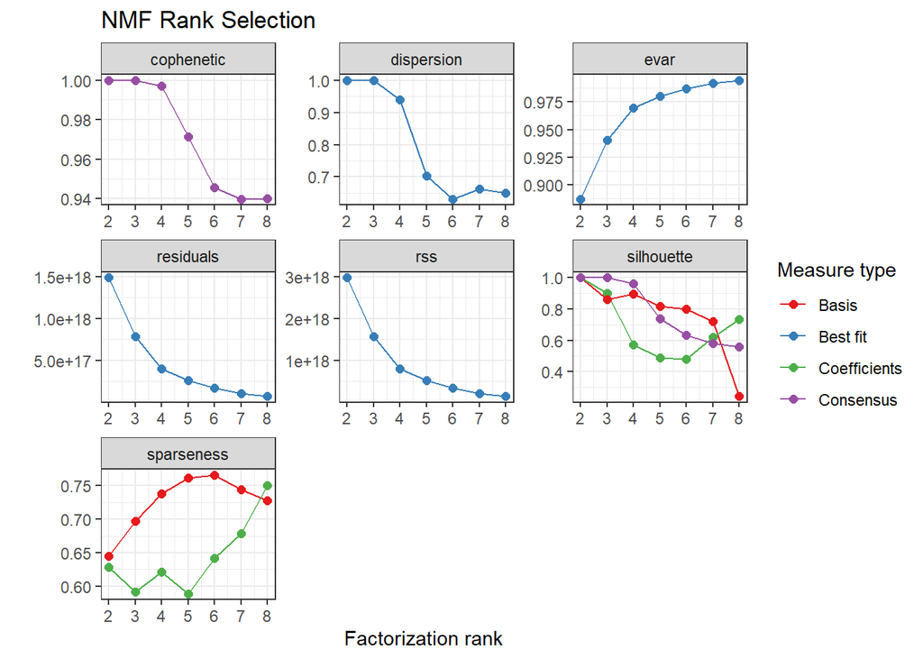

```r
nmf_results <- nmf(as.matrix(android_nonneg), rank = 2:8, method = "lee", nrun = 10)

# Plot metrics (higher cophenetic = better stability)
plot(nmf_results, main = "NMF Rank Selection")
```

Interpretation:

- **Cophenetic** is a correlation measure about the pairwise distance between points in the original dataand the pairwise distance between points in the reduced data (high cophenetic –> distances are better preserved)
- **Dispersion**: stability of NMF across runs
- **Evar**: variance captured by different ranks
- **Residuals**: based on V - WH
- **rss**: residual sum of squared
- **Silhouette**: it measures how well each sample fits its assigned cluster compared to other clusters (then, in terms of cohesion and separation
- **Sparseness**: sparsity in the observations (basis) or in the covariates (coefficients) for each run

A good choice can be rank=5 since we have high cophenetic, low rss and residuals, the explain variance is high.

Check dimension of W:

```r
nmf_result <- nmf(as.matrix(android_nonneg), rank = 5, method = "lee", nrun = 10)

V.hat <- fitted(nmf_result)
w <- basis(nmf_result) #  W
dim(w)
```

```
## [1] 10000     5
```

Check dimension of H:

```r
h_matrix <- coef(nmf_result) #  H
dim(h_matrix)
```

```
## [1]  5 56
```

#### **Autoencoder**

```r
h2o.init()
```

[output not shown]

```r
# Convert data to H2O frame
data_h2o <- as.h2o(android_data)
```

[output not shown]

```r
# Train autoencoder
autoencoder <- h2o.deeplearning(
  x = names(data_h2o),
  training_frame = data_h2o,
  autoencoder = TRUE,
  hidden = c(32, 8, 32),
  activation = "RectifierWithDropout",
  l1 = 1e-5,
  l2 = 1e-5,
  max_w2 = 10,
  adaptive_rate = TRUE,
  input_dropout_ratio = 0.1,
  hidden_dropout_ratios = c(0.1, 0.1, 0.1),
  epochs = 100
)
```

[output not shown]

```r
# Extract latent features
latent_rep <- h2o.deepfeatures(autoencoder, data_h2o, layer = 2) # we can extract second layer
```

[output not shown]

```r
latent_rep_df <- as.data.frame(latent_rep)
```

#### **Compare a model with different kind of features**

In this section, we are going to compare a random forest using

```r
android_true <- android_data |> mutate(Y = as.factor(label_android$Label))
pca_90 <- bake(prep(pca_recipe_90, training = android_data), new_data = android_data)
android_pca90 <- pca_90 |> mutate(Y = as.factor(label_android$Label))
pca_95 <- bake(prep(pca_recipe_95, training = android_data), new_data = android_data)
android_pca95 <- pca_95 |> mutate(Y = as.factor(label_android$Label))
android_nmf <- as.data.frame(w) |> mutate(Y = as.factor(label_android$Label))
android_autoencoder <- latent_rep_df |> mutate(Y = as.factor(label_android$Label))


set.seed(123)  # For reproducibility
split <- initial_split(android_true, prop = 0.8)
train_data <- training(split)
val_data <- testing(split)

# true features
android_recipe <- recipe(Y~., train_data) |>
  step_zv(all_predictors())

rf_spec <- rand_forest(mtry = 5, trees = 20, min_n = 20) |>
  set_engine("ranger", importance = "impurity") |>
  set_mode("classification")

# Create workflow
rf_wf <- workflow() |>
  add_recipe(android_recipe) |>
  add_model(rf_spec)

# Fit model
rf_fit <- parsnip::fit(rf_wf, data = train_data)

# Get predictions on validation data
val_preds_true <- predict(rf_fit, new_data = val_data) |>
  bind_cols(val_data)
metrics <- metric_set(accuracy, f_meas)

val_metrics_true <- metrics(val_preds_true, truth = Y, estimate = .pred_class)

#PCA 90%

set.seed(123)  # For reproducibility
split <- initial_split(android_pca90, prop = 0.8)
train_data <- training(split)
val_data <- testing(split)

# true features
android_recipe <- recipe(Y~., train_data) |>
  step_zv(all_predictors())

rf_spec <- rand_forest(mtry = 5, trees = 20, min_n = 20) |>
  set_engine("ranger", importance = "impurity") |>
  set_mode("classification")

# Create workflow
rf_wf <- workflow() |>
  add_recipe(android_recipe) |>
  add_model(rf_spec)

# Fit model
rf_fit <- parsnip::fit(rf_wf, data = train_data)

# Get predictions on validation data
val_preds_pca90 <- predict(rf_fit, new_data = val_data) |>
  bind_cols(val_data)

val_metrics_pca90 <- metrics(val_preds_pca90, truth = Y, estimate = .pred_class)

#PCA 95%

set.seed(123)  # For reproducibility
split <- initial_split(android_pca95, prop = 0.8)
train_data <- training(split)
val_data <- testing(split)

# true features
android_recipe <- recipe(Y~., train_data) |>
  step_zv(all_predictors())

rf_spec <- rand_forest(mtry = 5, trees = 20, min_n = 20) |>
  set_engine("ranger", importance = "impurity") |>
  set_mode("classification")

# Create workflow
rf_wf <- workflow() |>
  add_recipe(android_recipe) |>
  add_model(rf_spec)

# Fit model
rf_fit <- parsnip::fit(rf_wf, data = train_data)

# Get predictions on validation data
val_preds_pca95 <- predict(rf_fit, new_data = val_data) |>
  bind_cols(val_data)

val_metrics_pca95 <- metrics(val_preds_pca95, truth = Y, estimate = .pred_class)

# NMF

set.seed(123)  # For reproducibility
split <- initial_split(android_nmf, prop = 0.8)
train_data <- training(split)
val_data <- testing(split)

# true features
android_recipe <- recipe(Y~., train_data) |>
  step_zv(all_predictors())

rf_spec <- rand_forest(mtry = 5, trees = 20, min_n = 20) |>
  set_engine("ranger", importance = "impurity") |>
  set_mode("classification")

# Create workflow
rf_wf <- workflow() |>
  add_recipe(android_recipe) |>
  add_model(rf_spec)

# Fit model
rf_fit <- parsnip::fit(rf_wf, data = train_data)

# Get predictions on validation data
val_preds_nmf <- predict(rf_fit, new_data = val_data) |>
  bind_cols(val_data)

val_metrics_nmf <- metrics(val_preds_nmf, truth = Y, estimate = .pred_class)

# Autoencoder

set.seed(123)  # For reproducibility
split <- initial_split(android_autoencoder, prop = 0.8)
train_data <- training(split)
val_data <- testing(split)

# true features
android_recipe <- recipe(Y~., train_data) |>
  step_zv(all_predictors())

rf_spec <- rand_forest(mtry = 5, trees = 20, min_n = 20) |>
  set_engine("ranger", importance = "impurity") |>
  set_mode("classification")

# Create workflow
rf_wf <- workflow() |>
  add_recipe(android_recipe) |>
  add_model(rf_spec)

# Fit model
rf_fit <- parsnip::fit(rf_wf, data = train_data)

# Get predictions on validation data
val_preds_autoencoder <- predict(rf_fit, new_data = val_data) |>
  bind_cols(val_data)

val_metrics_autoencoder <- metrics(val_preds_nmf, truth = Y, estimate = .pred_class)

round(val_metrics_true$.estimate,4)
```

```
## [1] 0.4490 0.3104
```

```r
round(val_metrics_pca90$.estimate,4)
```

```
## [1] 0.3940 0.2706
```

```r
round(val_metrics_pca95$.estimate,4)
```

```
## [1] 0.3885 0.2700
```

```r
round(val_metrics_nmf$.estimate,4)
```

```
## [1] 0.4205 0.2864
```

```r
round(val_metrics_autoencoder$.estimate,4)
```

```
## [1] 0.4205 0.2864
```